# Week 7: Hypothesis Testing

Gabriel Vance

April 21, 2025

# Imports

```r
library(ggplot2)
library(dplyr)
library(tidyr)
# import libraries
library(cowplot)
library(glue)
library(pracma)
library(reshape)
library(scales)
library(truncnorm)
```

```r
data <- ("
        Higher  Lower
Value1      1      120
Value2      118      2
")

data_as_matrix <- as.matrix(read.table(textConnection(data), header = TRUE))
fisher.test(data_as_matrix)
```

```
##
##  Fisher's Exact Test for Count Data
##
## data:  data_as_matrix
## p-value < 2.2e-16
## alternative hypothesis: true odds ratio is not equal to 1
## 95 percent confidence interval:
##  0.0000000 0.0018362
## sample estimates:
##  odds ratio
## 0.000172163
```

Given that information, complete the following two examples. You’ll need R code along with Markdown. An experiment is executed to determine if spending too much time on social media hurts cognitive ability. The following data is a summary of that experiment.

Assuming the null hypothesis is that using social results in lower cognitive ability, and alpha is .05: What is the alternative hypothesis?

```r
# alternative hypothesis - This is the statement that contradicts the null hypothesis.
print("The alternative hypothesis to 'social media results in lower cognitive ability' is 'social media does not result in lower cognitive ability or results in higher cognitive ability'. However, NH is usually that 'nothing happened' or 'no difference'., so maybe the null hypothesis is that social media doesn't affect cognitive abiliy? We're going to press forward with the original definition and the way this was phrashed.")
```

[output not shown]

What is the p-value?

```r
test_result <- fisher.test(data_as_matrix)

# p-value -  measure probability of taining the observed results, assuming null hypotthesis is true. Low p-value = greater statistical signficance. 0.05 or lower is considered signficant
p_value <- test_result$p.value
cat("The p-value is: ", p_value)
```

```
## The p-value is:  4.892644e-66
```

Is the null hypothesis proven or disproven and why?

```r
cat("The null hypothesis is disproven because the p-value is less than 0.05. We reject the null hypothesis and accept the alterative hypothesis")
```

```
## The null hypothesis is disproven because the p-value is less than 0.05. We reject the null hypothesis and accept the alterative hypothesis
```

Is this a one-sided or two-sided test?

```r
cat("Because we used fisher.test() and did not specify the alternative parameter, the test is two-sided by default.")
```

```
## Because we used fisher.test() and did not specify the alternative parameter, the test is two-sided by default.
```

You toss a two-sided coin 100 times. Assuming the null hypothesis is that the coin is a fair coin and alpha is .05: What’s the alternative hypothesis? Is this a one-sided or two-sided test?

```r
print("The alternative hypothesis to 'the coin is a fair coin' is 'the coin is not a fair coin' and that it will land on heads or tails disporitaionally ")
```

```
## [1] "The alternative hypothesis to 'the coin is a fair coin' is 'the coin is not a fair coin' and that it will land on heads or tails disporitaionally "
```

```r
print("This is a two-sided test because we are looking for any difference in the distribution of heads and tails, not just one side.")
```

```
## [1] "This is a two-sided test because we are looking for any difference in the distribution of heads and tails, not just one side."
```

If the coin is heads 95 times, what is the p-value?

```r
p_val <- 2 * pbinom(5, size = 100, prob = 0.5)
print(p_val) #  1.252325e-22
```

```
## [1] 1.252325e-22
```

Is the null hypothesis proven or disproven and why?

```r
cat("The null hypothesis is disproven because the p-value is less than 0.05. We reject the null hypothesis and accept the alterative hypothesis")
```

```
## The null hypothesis is disproven because the p-value is less than 0.05. We reject the null hypothesis and accept the alterative hypothesis
```

Is this a one-sided or two-sided test, and why?

```r
print("Because we are looking for any difference in the distribution of heads and tails, not just one side, this is a two-sided test. We are looking for any difference in the distribution of heads and tails, not just one side.")
```

```
## [1] "Because we are looking for any difference in the distribution of heads and tails, not just one side, this is a two-sided test. We are looking for any difference in the distribution of heads and tails, not just one side."
```

Complete Exercise #1 from the text (at the end of Chapter 10).

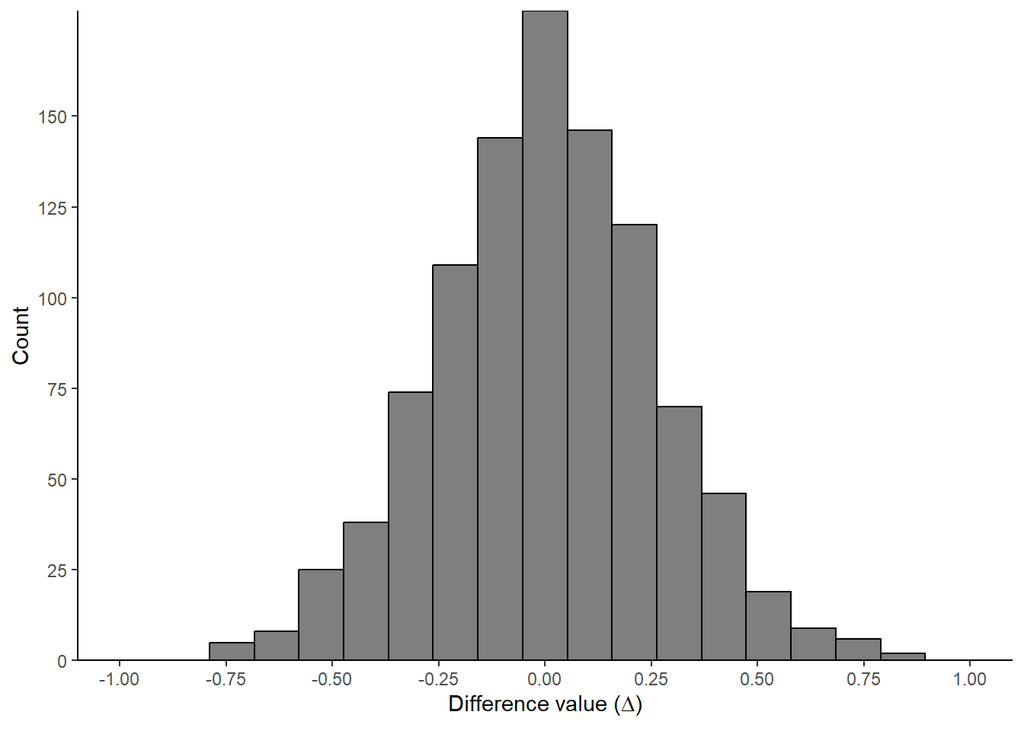

```r
# 10.1 says to copy code and modify it

#-------- Figure 10.2: Empirical distribution under H0 ---------#
#---------------------------------------------------------------#
N <- 1e2 # per group per sample
numExps <- 1e3
meandiff <- numeric(numExps)

# run the experiment
for (i in 1:numExps) {
  pre <- rtruncnorm(N, a = -5, b = 10, mean = 6, sd = 2)
  pst <- rtruncnorm(N, a = -5, b = 10, mean = 6, sd = 2)
  meandiff[i] <- mean(pst) - mean(pre)
}

df <- data.frame(x = meandiff)
fig <- ggplot(df, aes(x = x)) +
  geom_histogram(bins = 20, color = "black", fill = "gray50") +
  scale_x_continuous(breaks = seq(-1, 1, .25), limits = c(-1, 1)) +
  scale_y_continuous(breaks = seq(0, 150, 25), expand = c(0, 0)) +
  labs(x = expression(paste("Difference value (", Delta, ")")), y = "Count") +
  theme_classic()

fig
```

```r
p <- t.test(meandiff, mu = 0)$p.value

# Print the p-value
cat("The p-value from the t-test is:", p, "\n")
```

```
## The p-value from the t-test is: 0.6382459
```

Run tests 100 times and record the number of times the p-value is below threshold

```r
# Initialize variables to track false alarm rate
threshold <- 0.05 # Set the p-value threshold
false_alarm_count <- 0
num_repeats <- 100 # Number of times to run the t-test

# Run the t-test 100 times and count false alarms
for (i in 1:num_repeats) {
  # Perform the t-test on 'meandiff' values, assuming the null hypothesis mean is 0
  p_value <- t.test(meandiff, mu = 0)$p.value

  # Check if p-value is below the threshold
  if (p_value < threshold) {
    false_alarm_count <- false_alarm_count + 1
  }
}

# Calculate the false alarm rate
false_alarm_rate <- false_alarm_count / num_repeats

# Print the results
cat("The false alarm rate (p-value < 0.05) after 100 t-tests is:", false_alarm_rate, "\n")
```

```
## The false alarm rate (p-value < 0.05) after 100 t-tests is: 0
```

Embed this into a for loop that uses a threshold ranging from .001 to .9 Plot empirical false alarm rate.

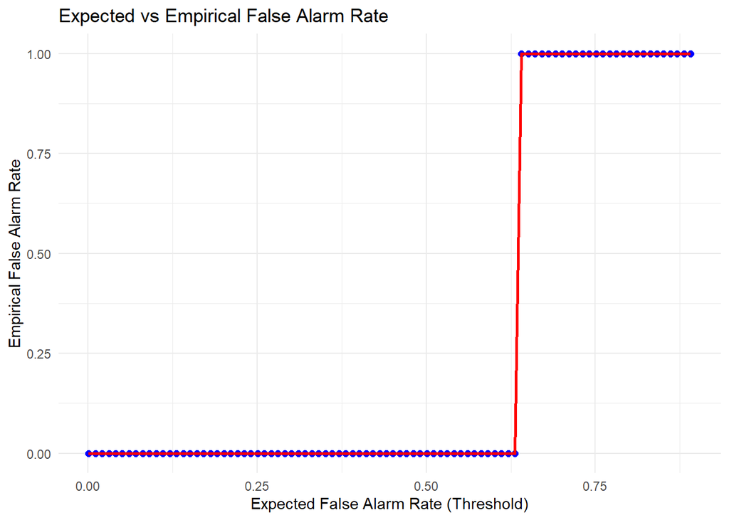

```r
# Initialize variables for tracking false alarm rates
thresholds <- seq(0.001, 0.9, by = 0.01) # Thresholds from 0.001 to 0.9
empirical_FA <- numeric(length(thresholds)) # To store empirical false alarm rates
expected_FA <- thresholds # Expected FA is just the threshold itself, from 0.001 to 0.9
num_repeats <- 100 # Number of repetitions for the experiment

# Run the experiment for each threshold and compute the empirical false alarm rate
for (t in 1:length(thresholds)) {
  threshold <- thresholds[t]
  false_alarm_count <- 0

  # Run 100 t-tests and count the number of false alarms (p-values below threshold)
  for (i in 1:num_repeats) {
    p_value <- t.test(meandiff, mu = 0)$p.value
    if (p_value < threshold) {
      false_alarm_count <- false_alarm_count + 1
    }
  }

  # Calculate the empirical false alarm rate for this threshold
  empirical_FA[t] <- false_alarm_count / num_repeats
}

# Create a data frame for plotting the expected vs. empirical false alarm rates
df_FA <- data.frame(
  threshold = thresholds,
  empirical_FA = empirical_FA,
  expected_FA = expected_FA
)

# Plot the expected vs empirical false alarm rate
fig_FA <- ggplot(df_FA, aes(x = expected_FA, y = empirical_FA)) +
  geom_point(color = "blue", size = 2) + # Plot the points
  geom_line(color = "red", size = 1) + # Add a line to connect the points
  labs(
    x = "Expected False Alarm Rate (Threshold)", y = "Empirical False Alarm Rate",
    title = "Expected vs Empirical False Alarm Rate"
  ) +
  theme_minimal()
# Display the plot
print(fig_FA)
```

```r
# Optionally, save the plot to a file
ggsave(filename = "expected_vs_empirical_FA.png", width = 8, height = 4, units = "in", dpi = 300)

# Print the final results
cat("Expected vs Empirical False Alarm Rate plot generated.\n")
```

```
## Expected vs Empirical False Alarm Rate plot generated.
```

Plot means and p-values

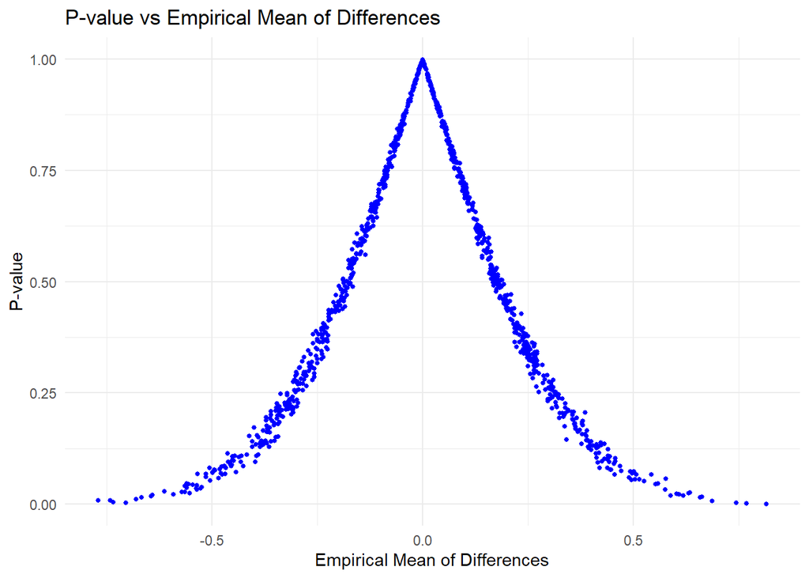

```r
#-------- Figure 10.2: Empirical distribution under H0 ---------#
#---------------------------------------------------------------#
N <- 1e2 # per group per sample
numExps <- 1e3 # number of experiments
meandiff <- numeric(numExps)
p_values <- numeric(numExps) # To store p-values from each t-test
empirical_means <- numeric(numExps) # To store empirical means for plotting

# Run the experiment to generate 'meandiff' and capture p-values from t-tests
for (i in 1:numExps) {
  pre <- rtruncnorm(N, a = -5, b = 10, mean = 6, sd = 2)
  pst <- rtruncnorm(N, a = -5, b = 10, mean = 6, sd = 2)
  meandiff[i] <- mean(pst) - mean(pre)
  empirical_means[i] <- mean(meandiff[i]) # Capture the empirical mean

  # Perform a t-test on the full samples (pre and pst) to calculate p-value
  p_values[i] <- t.test(pst, pre)$p.value
}

# Create a data frame for plotting p-values vs empirical means
df_empirical <- data.frame(
  empirical_mean = empirical_means,
  p_value = p_values
)

# Create the plot for p-values vs empirical means
fig_empirical <- ggplot(df_empirical, aes(x = empirical_mean, y = p_value)) +
  geom_point(color = "blue", size = 1) +
  labs(x = "Empirical Mean of Differences", y = "P-value", title = "P-value vs Empirical Mean of Differences") +
  theme_minimal()

# Display the plot
print(fig_empirical)
```

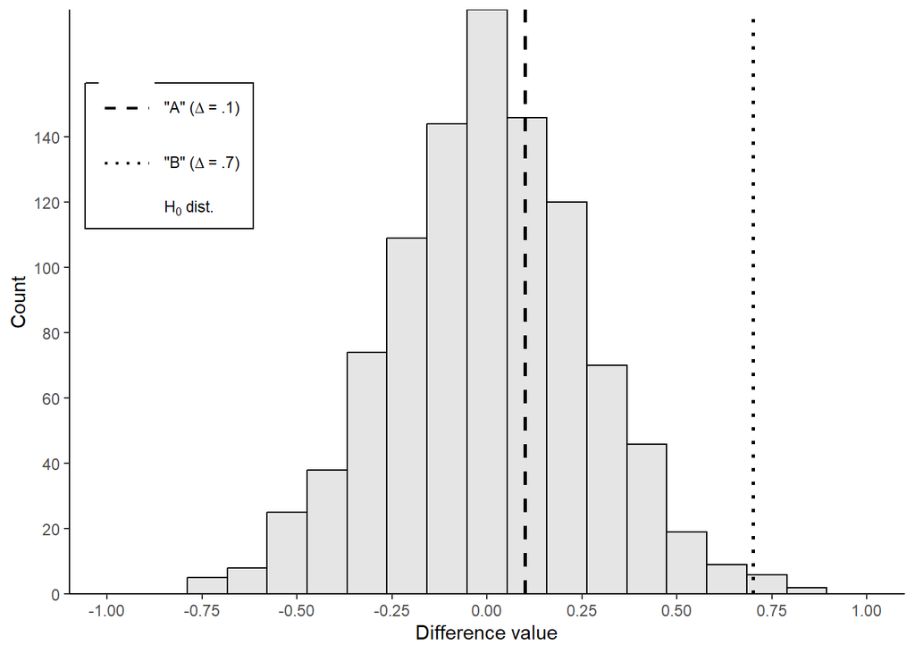

```r
#-------- Figure 10.3: Distribution assuming H0 is true ---------#
#----------------------------------------------------------------#
fig <- ggplot(df, aes(x = x)) +
  geom_histogram(aes(linetype = "H"), bins = 20, color = "black", fill = "gray90", show.legend = FALSE) +
  geom_vline(aes(xintercept = .1, linetype = "b"), lwd = 1, key_glyph = "path") +
  geom_vline(aes(xintercept = .7, linetype = "c"), lwd = 1, key_glyph = "path") +
  scale_x_continuous(breaks = seq(-1, 1, .25), limits = c(-1, 1)) +
  scale_y_continuous(breaks = seq(0, 140, 20), expand = c(0, 0)) +
  scale_linetype_manual(
    labels = c(
      expression(paste('"A" (', Delta, " = .1)")),
      expression(paste('"B" (', Delta, " = .7)")),
      expression(paste("H"[0], " dist."))
    ),
    values = c(H = "solid", b = "dashed", c = "dotted")
  ) +
  labs(x = "Difference value", y = "Count") +
  theme_classic() +
  guides(linetype = guide_legend(override.aes = list(
    linetype = c("dashed", "dotted", "solid"),
    size = 10, linewidth = c(.75, .75, 3),
    color = c("black", "black", "gray")
  ))) +
  theme(
    legend.title = element_blank(),
    legend.position = c(.12, .75),
    legend.text.align = 0,
    legend.background = element_blank(),
    legend.box.background = element_rect(colour = "black"),
    legend.box.margin = margin(-7, 2, -2, 2)
  ) # top, right, bottom, left
fig
```

create and plot a pdf of one distriubtion using dt(t,df) where t is a vector of t-values between -4 and +_4. use df=20.

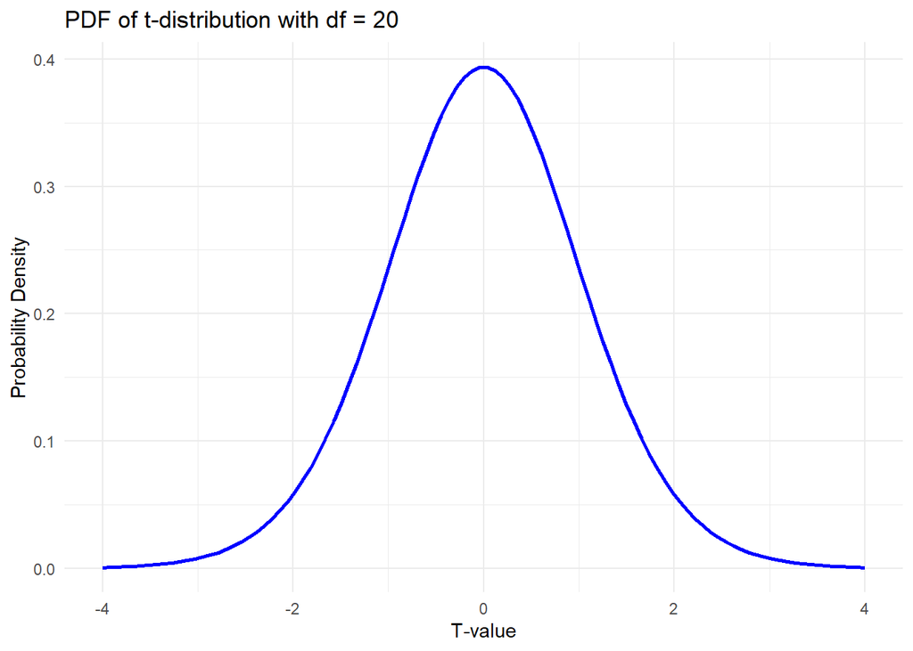

```r
# Define a range of t-values from -4 to +4
t_values <- seq(-4, 4, length.out = 100)

# Calculate the probability density for each t-value using dt() with df = 20
pdf_values <- dt(t_values, df = 20)

# Create a data frame for plotting
df_pdf <- data.frame(t_values = t_values, pdf_values = pdf_values)

# Plot the PDF of the t-distribution
fig_pdf <- ggplot(df_pdf, aes(x = t_values, y = pdf_values)) +
  geom_line(color = "blue", size = 1) +
  labs(x = "T-value", y = "Probability Density", title = "PDF of t-distribution with df = 20") +
  theme_minimal()

# Display the plot
print(fig_pdf)
```

in a for loop, create many t-distriubtions using the same t-values but df values, ranging from 4 to 40 in integer steps. plot distrubtions, scale y-axis to proability

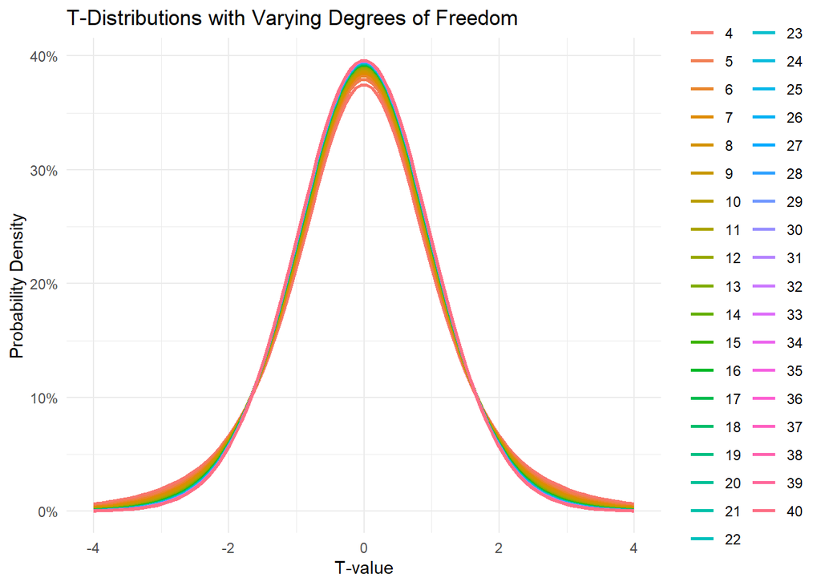

```r
# Define a range of t-values from -4 to +4
t_values <- seq(-4, 4, length.out = 100)

# Create an empty data frame to store results for plotting
df_t_distributions <- data.frame()

# Loop through degrees of freedom (from 4 to 40) and compute the t-distribution for each
for (df in 4:40) {
  # Calculate the probability density for each t-value using dt() with the current df
  pdf_values <- dt(t_values, df = df)

  # Create a data frame for the current distribution
  temp_df <- data.frame(
    t_values = t_values,
    pdf_values = pdf_values,
    df = as.factor(df) # Store the degrees of freedom for legend
  )

  # Append the result to the main data frame
  df_t_distributions <- rbind(df_t_distributions, temp_df)
}

# Plot all the t-distributions on the same plot
fig_t_distributions <- ggplot(df_t_distributions, aes(x = t_values, y = pdf_values, color = df)) +
  geom_line(size = 1) +
  labs(x = "T-value", y = "Probability Density", title = "T-Distributions with Varying Degrees of Freedom") +
  scale_y_continuous(labels = scales::percent) + # Scale y-axis to probability density
  theme_minimal() +
  theme(legend.title = element_blank()) # Remove legend title for clarity

# Display the plot
print(fig_t_distributions)
```

Cohen’s book from 10.4

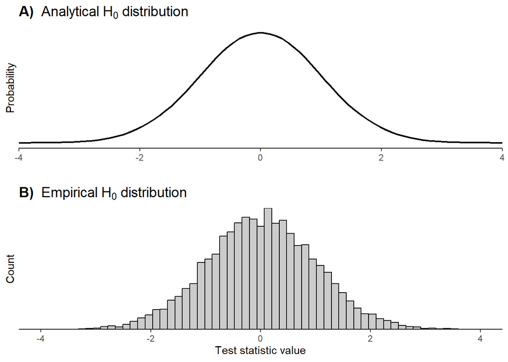

```r
#-------- Figure 10.4: Analytical vs. empirical H0 distribution ---------#
#------------------------------------------------------------------------#
empirical <- rnorm(1e4)
x <- seq(-4, 4, length = 1001)
analytical <- dnorm(x) * diff(x[1:2])

fig_A <- ggplot(data.frame(x = x, y = analytical), aes(x = x, y = y)) +
  geom_smooth(color = "black", lwd = .75) +
  scale_x_continuous(expand = c(0, 0)) +
  scale_y_continuous(breaks = NULL) +
  labs(
    title = expression(paste(bold("A)  "), "Analytical ", "H"[0], " distribution")),
    x = "", y = "Probability"
  ) +
  theme_classic() +
  theme(plot.title = element_text(size = 14))

fig_B <- ggplot(data.frame(x = empirical), aes(x = x)) +
  geom_histogram(bins = 60, color = "black", fill = "gray80") +
  scale_x_continuous(limit = c(-4, 4)) +
  scale_y_continuous(breaks = NULL, expand = c(0, 0)) +
  labs(
    title = expression(paste(bold("B)  "), "Empirical ", "H"[0], " distribution")),
    x = "Test statistic value", y = "Count"
  ) +
  theme_classic() +
  theme(plot.title = element_text(size = 14))

fig <- plot_grid(fig_A, fig_B, ncol = 1)
fig
```

Start by creating a family of k-40 random p-vales as u^2 then implement the following steps:

1. sort the p-values

```r
# Generate random p-values (e.g., using a uniform distribution)
set.seed(123) # For reproducibility
k <- 40
u <- runif(k) # Generate k random numbers from uniform distribution
pvals <- u^2 # p-values generated from u^2 (uniform squared)

# Step 1: Sort the p-values
sorted_pvals <- sort(pvals)

# Print the sorted p-values
print("Sorted p-values:")
```

```
## [1] "Sorted p-values:"
```

```r
print(sorted_pvals)
```

```
##  [1] 0.0006058335 0.0017690044 0.0020753946 0.0105934903 0.0216424252
##  [6] 0.0468323947 0.0536505044 0.0605591730 0.0827008301 0.0836133537
## [11] 0.1012391536 0.1075319981 0.1672621226 0.2055118572 0.2084970165
## [16] 0.2282889900 0.2788954065 0.2960078392 0.3040805752 0.3279090130
## [21] 0.3530047405 0.4102489785 0.4299500950 0.4591019660 0.4770737816
## [26] 0.4799765596 0.5020154243 0.5752608701 0.6214249866 0.6327684126
## [31] 0.7797197358 0.7912801948 0.7964117508 0.8096849774 0.8141435668
## [36] 0.8844787128 0.9110772162 0.9155300508 0.9274156725 0.9885723887
```

2. compute linear-interpolated p-values set as v/k where v is a vector of integers

```r
# Create a vector of integers from 1 to k (v)
v <- 1:k

# Compute the linear-interpolated p-values as v/k
linear_interpolated_pvals <- v / k

# Display the linear-interpolated p-values
print("Linear-interpolated p-values (v/k):")
```

```
## [1] "Linear-interpolated p-values (v/k):"
```

```r
print(linear_interpolated_pvals)
```

```
##  [1] 0.025 0.050 0.075 0.100 0.125 0.150 0.175 0.200 0.225 0.250 0.275 0.300
## [13] 0.325 0.350 0.375 0.400 0.425 0.450 0.475 0.500 0.525 0.550 0.575 0.600
## [25] 0.625 0.650 0.675 0.700 0.725 0.750 0.775 0.800 0.825 0.850 0.875 0.900
## [37] 0.925 0.950 0.975 1.000
```

3. compute adjusted p-values by dividing the sorted p-values by the linear interpolated p-values

```r
# Compute the adjusted p-values
adjusted_pvals <- sorted_pvals / linear_interpolated_pvals

# Display the adjusted p-values
print("Adjusted p-values (sorted p-values / linear-interpolated p-values):")
```

```
## [1] "Adjusted p-values (sorted p-values / linear-interpolated p-values):"
```

```r
print(adjusted_pvals)
```

```
##  [1] 0.02423334 0.03538009 0.02767193 0.10593490 0.17313940 0.31221596
##  [7] 0.30657431 0.30279586 0.36755924 0.33445341 0.36814238 0.35843999
## [13] 0.51465268 0.58717673 0.55599204 0.57072247 0.65622449 0.65779520
## [19] 0.64016963 0.65581803 0.67238998 0.74590723 0.74773930 0.76516994
## [25] 0.76331805 0.73842548 0.74372655 0.82180124 0.85713791 0.84369122
## [31] 1.00608998 0.98910024 0.96534758 0.95257056 0.93044979 0.98275413
## [37] 0.98494834 0.96371584 0.95119556 0.98857239
```

Use function fdrcorrection() which is contained in p.adjust(pvaels,“BH”)

Organize results into a graph

```r
# Apply the Benjamini-Hochberg correction
fdr_corrected_pvals <- p.adjust(sorted_pvals, method = "BH")

# Display the FDR-corrected p-values
print("FDR-corrected p-values (Benjamini-Hochberg):")
```

```
## [1] "FDR-corrected p-values (Benjamini-Hochberg):"
```

```r
print(fdr_corrected_pvals)
```

```
##  [1] 0.02423334 0.02767193 0.02767193 0.10593490 0.17313940 0.30279586
##  [7] 0.30279586 0.30279586 0.33445341 0.33445341 0.35843999 0.35843999
## [13] 0.51465268 0.55599204 0.55599204 0.57072247 0.64016963 0.64016963
## [19] 0.64016963 0.65581803 0.67238998 0.73842548 0.73842548 0.73842548
## [25] 0.73842548 0.73842548 0.74372655 0.82180124 0.84369122 0.84369122
## [31] 0.93044979 0.93044979 0.93044979 0.93044979 0.93044979 0.95119556
## [37] 0.95119556 0.95119556 0.95119556 0.98857239
```

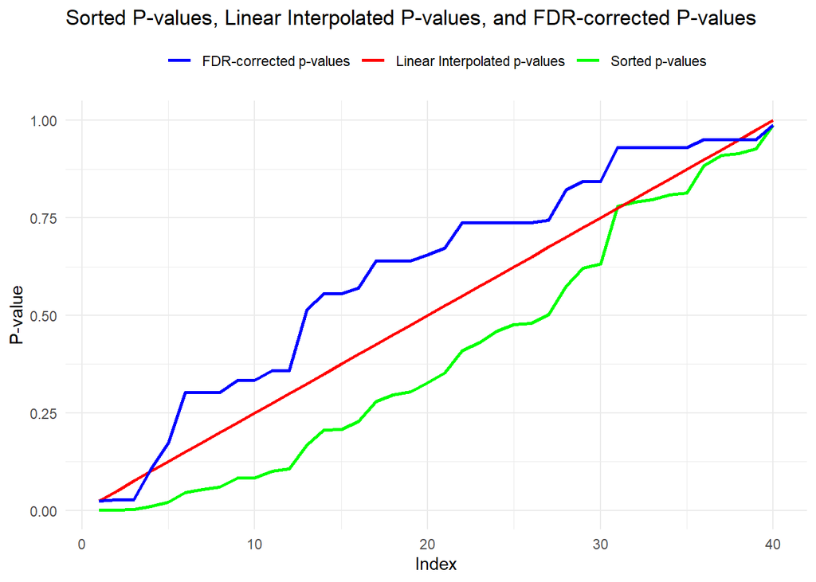

```r
# Step 5: Organize results into a graph

# Create a data frame with the sorted p-values, linear-interpolated p-values, and FDR-corrected p-values
df_results <- data.frame(
  Sorted_pvals = sorted_pvals,
  Linear_interpolated_pvals = linear_interpolated_pvals,
  FDR_corrected_pvals = fdr_corrected_pvals
)

# Plot the results: Sorted p-values, linear-interpolated p-values, and FDR-corrected p-values
library(ggplot2)

fig_fdr <- ggplot(df_results, aes(x = 1:k)) +
  geom_line(aes(y = Sorted_pvals, color = "Sorted p-values"), size = 1) +
  geom_line(aes(y = Linear_interpolated_pvals, color = "Linear Interpolated p-values"), size = 1) +
  geom_line(aes(y = FDR_corrected_pvals, color = "FDR-corrected p-values"), size = 1) +
  labs(
    x = "Index",
    y = "P-value",
    title = "Sorted P-values, Linear Interpolated P-values, and FDR-corrected P-values"
  ) +
  scale_color_manual(values = c("blue", "red", "green")) +
  theme_minimal() +
  theme(
    legend.title = element_blank(),
    legend.position = "top"
  )

# Display the plot
print(fig_fdr)
```

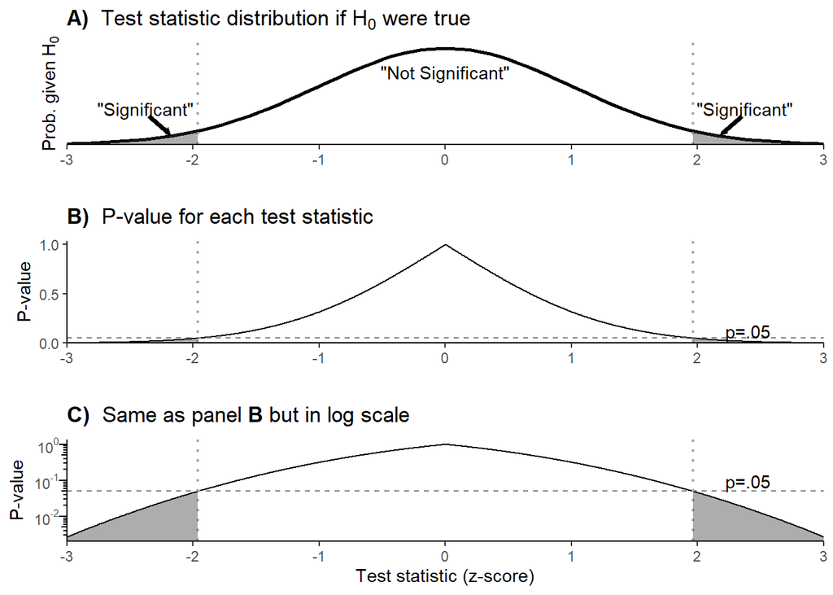

```r
#-------- Figure 10.5: p-values and thresholds ---------#
#-------------------------------------------------------#
# create a Gaussian probability curve
zvals <- seq(-3, 3, length = 1001)
zpdf <- dnorm(zvals)

# plot the probability function and the vertical lines
df1 <- data.frame(x = zvals, y = zpdf)
fig_A <- ggplot(df1, aes(x = x, y = y)) +
  geom_smooth(color = "black") +
  scale_x_continuous(limit = c(head(zvals, 1), tail(zvals, 1)), expand = c(0, 0)) +
  scale_y_continuous(limit = c(0, .42), breaks = NULL, expand = c(0, 0)) +
  labs(x = "", y = expression(paste("Prob. given ", "H"[0]))) +
  theme_classic()

# two-tailed p-values
mn_idx <- which.min(zvals**2)
pvalsL <- pnorm(zvals[1:mn_idx])
pvalsR <- 1 - pnorm(zvals[(mn_idx + 1):length(zvals)])
pvals2 <- 2 * c(pvalsL, pvalsR)

# plot the probability function
df2 <- data.frame(x = zvals, y = pvals2)
fig_B <- ggplot(df2, aes(x = x, y = y)) +
  geom_line(color = "black") +
  geom_hline(yintercept = .05, color = "gray50", linetype = "dashed") +
  scale_x_continuous(limit = c(head(zvals, 1), tail(zvals, 1)), expand = c(0, 0)) +
  labs(x = "", y = "P-value") +
  theme_classic()

# draw vertical lines
vline1 <- geom_vline(aes(xintercept = zvals[which.min((zvals - qnorm(.025))**2)]),
  color = "darkgray",
  linetype = "dotted", linewidth = .75
)
vline2 <- geom_vline(aes(xintercept = zvals[which.min((zvals - qnorm(.975))**2)]),
  color = "darkgray",
  linetype = "dotted", linewidth = .75
)
fig_A <- fig_A + vline1 + vline2
fig_B <- fig_B + vline1 + vline2

# draw patches for significant regions
zidx <- which.min((zvals - qnorm(.025))**2)
fig_A <- fig_A + geom_ribbon(data = subset(df1, x <= x[zidx]), aes(ymin = 0, ymax = y), alpha = .4)
fig_B <- fig_B + geom_ribbon(data = subset(df2, x <= x[zidx]), aes(ymin = 0, ymax = y), alpha = .4)

zidx <- which.min((zvals - qnorm(.975))**2)
fig_A <- fig_A + geom_ribbon(data = subset(df1, x >= x[zidx]), aes(ymin = 0, ymax = y), alpha = .4)
fig_B <- fig_B + geom_ribbon(data = subset(df2, x >= x[zidx]), aes(ymin = 0, ymax = y), alpha = .4)

fig_C <- fig_B

# indicators
fig_A <- fig_A + annotate("text", x = 0, y = .3, label = '\"Not Significant\"') +
  annotate("segment",
    x = -2.35, xend = -2.2, y = .12, yend = .05, lwd = 1.25, linejoin = "mitre",
    arrow = arrow(type = "closed", length = unit(.02, "npc"))
  ) +
  annotate("text", x = -2.375, y = .15, label = '\"Significant\"') +
  annotate("segment",
    x = 2.35, xend = 2.2, y = .12, yend = .05, lwd = 1.25, linejoin = "mitre",
    arrow = arrow(type = "closed", length = unit(.02, "npc"))
  ) +
  annotate("text", x = 2.375, y = .15, label = '\"Significant\"')

fig_B <- fig_B + annotate("text", x = 2.4, y = .12, label = "p=.05")
fig_C <- fig_C + annotate("text", x = 2.4, y = .0975, label = "p=.05")

# panel titles
fig_A <- fig_A + ggtitle(expression(paste(bold("A)  "), "Test statistic distribution if ", "H"[0], " were true")))
fig_B <- fig_B + ggtitle(expression(paste(bold("B)  "), "P-value for each test statistic")))
fig_C <- fig_C + ggtitle(expression(paste(bold("C)  "), "Same as panel ", bold("B"), " but in log scale")))

fig_B <- fig_B + scale_y_continuous(limits = c(0, 1.03), breaks = seq(0, 1, .5), expand = c(0, 0))
fig_C <- fig_C + xlab("Test statistic (z-score)") +
  scale_y_log10(labels = trans_format("log10", math_format(10^.x))) +
  annotation_logticks(
    sides = "l", outside = TRUE, size = .25,
    short = unit(.075, "cm"), mid = unit(.125, "cm"), long = unit(.175, "cm")
  ) +
  coord_cartesian(clip = "off") +
  theme(axis.ticks.y = element_blank())
fig <- plot_grid(fig_A, fig_B, fig_C, ncol = 1, align = "v", axis = "l")
fig
```

```r
ggsave(filename = "hyp_sigRegionsZandP.png", width = 7, height = 7, units = "in", dpi = 300)
```

```r
# Apply FDR correction to the p-values using p.adjust()
fdr_corrected_pvals <- p.adjust(pvals2, method = "BH")

# Print FDR-corrected p-values
cat("FDR-corrected p-values (Benjamini-Hochberg):\n")
```

```
## FDR-corrected p-values (Benjamini-Hochberg):
```

```r
print(fdr_corrected_pvals)
```

[output not shown]

[output cut: 152 more lines]

```r
# Identify significant results (FDR-corrected p-values below 0.05)
significant_idx <- which(fdr_corrected_pvals < 0.05)

cat("Significant results (FDR-corrected p-value < 0.05):\n")
```

```
## Significant results (FDR-corrected p-value < 0.05):
```

```r
print(significant_idx) # This was 0...not sure if it was expected.
```

```
## integer(0)
```

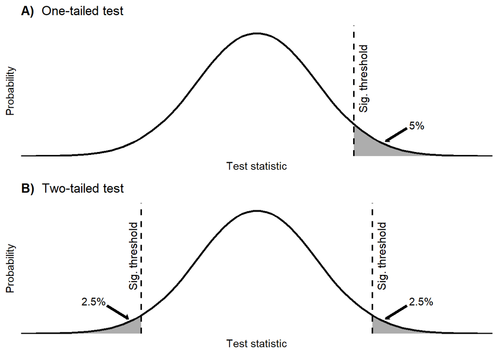

```r
#-------- Figure 10.6: H0 distribution with critical value ---------#
#-------------------------------------------------------------------#
# create a Gaussian probability curve
x <- seq(-4, 4, length = 1001)
gpdf <- dnorm(x)

# the find the indices of the 95% of the distribution
ubndi <- which.min(abs(x - qnorm(.95)))
df <- data.frame(x = x, y = gpdf)
fig_0 <- ggplot(df, aes(x = x, y = y)) +
  geom_smooth(color = "black") +
  scale_x_continuous(limits = c(head(x, 1), tail(x, 1)), expand = c(0, 0)) +
  scale_y_continuous(limits = c(0, .42), expand = c(0, 0)) +
  labs(x = "Test statistic", y = "Probability") +
  theme_classic() +
  theme(line = element_blank(), axis.text = element_blank())

fig_A <- fig_0 + ggtitle(expression(paste(bold("A)  "), "One-tailed test")))

# create patches for the significant area
fig_A <- fig_A + geom_ribbon(
  data = subset(df, x >= x[ubndi]),
  aes(ymin = 0, ymax = y), alpha = .4
)

# annotations
tailx <- which.min(abs(x - 2.2))
fig_A <- fig_A + annotate("text", x = 2.72, y = .1, label = "5%") +
  annotate("segment",
    x = 2.55, xend = 2.2, y = 0.09, yend = 0.05, lwd = 1.5, linejoin = "mitre",
    arrow = arrow(type = "closed", length = unit(.01, "npc"))
  )

# significance threshold line
fig_A <- fig_A + geom_vline(xintercept = x[ubndi], linetype = "dashed", lwd = .75) +
  annotate("text", x = x[ubndi] + .15, y = .25, size = 4, label = "Sig. threshold", angle = 90)

# the find the indices of the 2.5% and 97.5%
lbndi <- which.min(abs(x - qnorm(.025)))
ubndi <- which.min(abs(x - qnorm(1 - .025)))

# plot the probability function and the vertical lines
fig_B <- fig_0 + ggtitle(expression(paste(bold("B)  "), "Two-tailed test")))


# now create patches for the significant area
fig_B <- fig_B + geom_ribbon(data = subset(df, x <= x[lbndi]), aes(ymin = 0, ymax = y), alpha = .4) +
  geom_ribbon(data = subset(df, x >= x[ubndi]), aes(ymin = 0, ymax = y), alpha = .4)

# significance threshold line
fig_B <- fig_B + geom_vline(xintercept = x[lbndi], linetype = "dashed", lwd = .75) +
  geom_vline(xintercept = x[ubndi], linetype = "dashed", lwd = .75)

# annotations
fig_B <- fig_B + annotate("text", x = x[lbndi] - .15, y = .25, size = 4, label = "Sig. threshold", angle = 90) +
  annotate("text", x = x[ubndi] + .15, y = .25, size = 4, label = "Sig. threshold", angle = 90) +
  annotate("text", x = -2.77, y = .105, label = "2.5%") +
  annotate("segment",
    x = -2.55, xend = -2.2, y = 0.09, yend = 0.05, lwd = 1.5, linejoin = "mitre",
    arrow = arrow(type = "closed", length = unit(.01, "npc"))
  ) +
  annotate("text", x = 2.79, y = .105, label = "2.5%") +
  annotate("segment",
    x = 2.55, xend = 2.2, y = 0.09, yend = 0.05, lwd = 1.5, linejoin = "mitre",
    arrow = arrow(type = "closed", length = unit(.01, "npc"))
  )

fig <- plot_grid(fig_A, fig_B, ncol = 1, align = "v")
fig
```

```r
ggsave(filename = "hyp_tails.png", width = 7, height = 5, units = "in", dpi = 300)
```

start by creating a set of 100 random p-valuyes as p=u^2 using a threshold of .05 compute report percent of p-values that are subtreshold.

it should read:

FDR led to X% significant tests. Bonferroni led to Z% significant tests.

```r
# Set the seed for reproducibility
set.seed(123)

# Generate 100 random p-values
k <- 100
u <- runif(k)
pvals <- u^2

# Define the threshold
threshold <- 0.05

# Compute percentage of p-values below the threshold
percent_below_threshold <- sum(pvals < threshold) / k * 100

# Apply FDR
fdr_corrected_pvals <- p.adjust(pvals, method = "BH")
percent_significant_fdr <- sum(fdr_corrected_pvals < threshold) / k * 100

# Apply Bonferroni correction
bonferroni_corrected_pvals <- p.adjust(pvals, method = "bonferroni")
percent_significant_bonferroni <- sum(bonferroni_corrected_pvals < threshold) / k * 100

# Output the results
cat("FDR led to", round(percent_significant_fdr, 2), "% significant tests.\n")
```

```
## FDR led to 5 % significant tests.
```

```r
cat("Bonferroni led to", round(percent_significant_bonferroni, 2), "% significant tests.\n")
```

```
## Bonferroni led to 1 % significant tests.
```

compute and report the mean and standard deviation portion subthreshold p-values. put the code into for loop over 100 iterations, creating 100 p-values

FDR: mean of X% (str 1.23) significant tests Bonferroni: mean of Z% (str 1.23) significant tests

```r
# Set the number of iterations
iterations <- 100

# Initialize vectors to store the percentage of significant tests for each iteration
fdr_percentages <- numeric(iterations)
bonferroni_percentages <- numeric(iterations)

# Run the simulation over 100 iterations
set.seed(123) # For reproducibility
for (i in 1:iterations) {
  # Generate 100 random p-values
  u <- runif(100)
  pvals <- u^2

  # Apply FDR correction using Benjamini-Hochberg method
  fdr_corrected_pvals <- p.adjust(pvals, method = "BH")

  # Apply Bonferroni correction
  bonferroni_corrected_pvals <- p.adjust(pvals, method = "bonferroni")

  # Compute percentage of significant tests (p < 0.05)
  fdr_percentages[i] <- sum(fdr_corrected_pvals < 0.05) / length(pvals) * 100
  bonferroni_percentages[i] <- sum(bonferroni_corrected_pvals < 0.05) / length(pvals) * 100
}

# Compute the mean and standard deviation for both methods
mean_fdr <- mean(fdr_percentages)
sd_fdr <- sd(fdr_percentages)
mean_bonferroni <- mean(bonferroni_percentages)
sd_bonferroni <- sd(bonferroni_percentages)

# Report the results
cat("FDR: mean of", round(mean_fdr, 2), "% significant tests (SD =", round(sd_fdr, 2), ")\n")
```

```
## FDR: mean of 6.22 % significant tests (SD = 3.56 )
```

```r
cat("Bonferroni: mean of", round(mean_bonferroni, 2), "% significant tests (SD =", round(sd_bonferroni, 2), ")\n")
```

```
## Bonferroni: mean of 2.27 % significant tests (SD = 1.4 )
```

There is a difference between the two. What does the difference mean? Which method is more correct, or better?

```r
cat("FDR allows more significant tests but may accept more false positives.\n")
```

```
## FDR allows more significant tests but may accept more false positives.
```

```r
cat("Bonferroni is more strict, leading to fewer significant tests but controlling false positives more strictly.\n")
```

```
## Bonferroni is more strict, leading to fewer significant tests but controlling false positives more strictly.
```

```r
cat("There isn't a one-size fits all to make one better than the other. They are used in different contexts.\n")
```

```
## There isn't a one-size fits all to make one better than the other. They are used in different contexts.
```

Embed the code from exercise 6 with 100 repetitions in another for loop that varies the number of p-values in each set, from 2 to 500, logarithmetically spaced sets. Vizualize results in a plot.

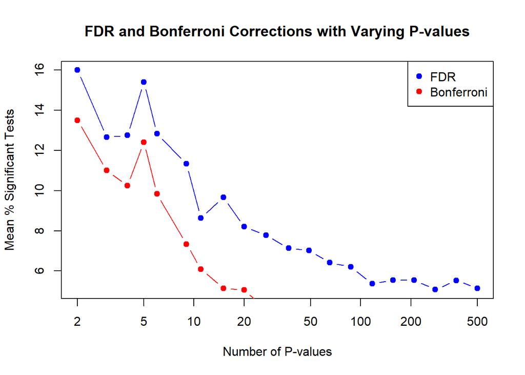

```r
# Set the number of iterations for each set of p-values
iterations <- 100

# Set the number of p-values for each iteration, varying from 2 to 500 logarithmically spaced
num_pvals <- round(10^(seq(log10(2), log10(500), length.out = 20)))

# Initialize vectors to store the percentage of significant tests for each number of p-values
fdr_percentages_all <- numeric(length(num_pvals))
bonferroni_percentages_all <- numeric(length(num_pvals))

# Loop through the different numbers of p-values
for (j in 1:length(num_pvals)) {
  # Initialize vectors to store the percentages for this specific number of p-values
  fdr_percentages <- numeric(iterations)
  bonferroni_percentages <- numeric(iterations)

  for (i in 1:iterations) {
    # Generate random p-values for the current number of p-values
    pvals <- runif(num_pvals[j])^2

    # Apply FDR correction using Benjamini-Hochberg method
    fdr_corrected_pvals <- p.adjust(pvals, method = "BH")

    # Apply Bonferroni correction
    bonferroni_corrected_pvals <- p.adjust(pvals, method = "bonferroni")

    # Compute percentage of significant tests (p < 0.05)
    fdr_percentages[i] <- sum(fdr_corrected_pvals < 0.05) / length(pvals) * 100
    bonferroni_percentages[i] <- sum(bonferroni_corrected_pvals < 0.05) / length(pvals) * 100
  }

  # Store the mean percentage for the current number of p-values
  fdr_percentages_all[j] <- mean(fdr_percentages)
  bonferroni_percentages_all[j] <- mean(bonferroni_percentages)
}

# Create a plot to visualize the results
plot(num_pvals, fdr_percentages_all,
  type = "b", col = "blue", pch = 19, xlab = "Number of P-values",
  ylab = "Mean % Significant Tests", log = "x",
  main = "FDR and Bonferroni Corrections with Varying P-values"
)
lines(num_pvals, bonferroni_percentages_all, type = "b", col = "red", pch = 19)
legend("topright", legend = c("FDR", "Bonferroni"), col = c("blue", "red"), pch = 19)
```

The number of subthresholds drops with Bonferroni correction, while the number remains roughly constant for FDR. Why does this happen?

```r
# Note, my chart doesn't match the one from the book. While FDR lasts until 500, it is not consistent as it is in the book.
print("Bonferroni correction is strict. As the number of tests increases, fewer p-values are significant.")
```

```
## [1] "Bonferroni correction is strict. As the number of tests increases, fewer p-values are significant."
```

```r
print("FDR correction is more flexible. It allows more p-values to stay significant as the number of tests increases.")
```

```
## [1] "FDR correction is more flexible. It allows more p-values to stay significant as the number of tests increases."
```

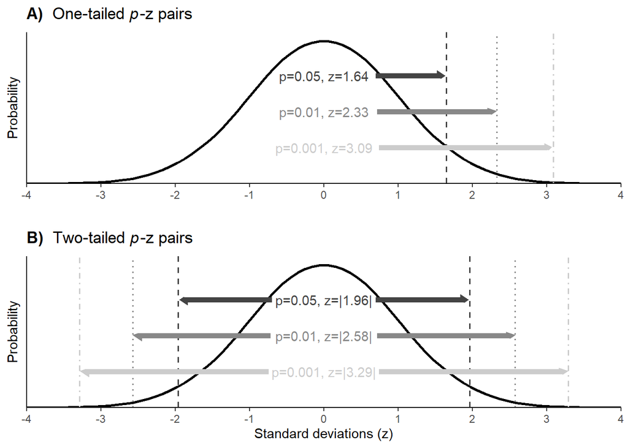

```r
#-------- Figure 10.8: p-z pairs ---------#
#-----------------------------------------#
# critical p-values to draw
ps2draw <- c(.05, .01, .001)

stds <- seq(-4, 4, length = 1001)
probs <- dnorm(stds)

# draw the lines
fig_A <- ggplot(data.frame(x = stds, y = probs), aes(x = x, y = y)) +
  geom_smooth(color = "black") +
  scale_x_continuous(breaks = seq(head(stds, 1), tail(stds, 1), 1), expand = c(0, 0)) +
  scale_y_continuous(limits = c(0, .42), expand = c(0, 0)) +
  labs(x = "", y = "Probability") +
  theme_classic() +
  theme(axis.ticks.y = element_blank(), axis.text.y = element_blank())

fig_B <- fig_A


## one-tailed
styles <- c("dashed", "dotted", "dotdash")
for (i in seq_along(ps2draw)) {
  zval <- qnorm(1 - ps2draw[i])
  c <- i / length(ps2draw) * .8
  fig_A <- fig_A + geom_vline(xintercept = zval, color = rgb(c, c, c), lwd = .575, linetype = styles[i]) +
    annotate("text",
      x = 0, y = .2 - (i - 2) / 10, color = rgb(c, c, c),
      label = glue("p=", ps2draw[i], ", z=", format(round(zval, 2), nsmall = 2))
    ) +
    annotate("segment",
      x = .7 + (i - 1) * .02, xend = zval - .075, y = .2 - (i - 2) / 10, yend = .2 - (i - 2) / 10,
      color = rgb(c, c, c), lwd = 2, linejoin = "mitre", arrow = arrow(type = "closed", length = unit(.01, "npc"))
    )
}

## two-tailed
for (i in seq_along(ps2draw)) {
  # z-value for this p-value
  zval <- qnorm(ps2draw[i] / 2)

  # vertical line
  c <- i / length(ps2draw) * .8 # line color
  fig_B <- fig_B + geom_vline(xintercept = -zval, color = rgb(c, c, c), lwd = .575, linetype = styles[i]) +
    geom_vline(xintercept = zval, color = rgb(c, c, c), lwd = .575, linetype = styles[i]) +
    annotate("text",
      x = 0, y = .2 - (i - 2) / 10, color = rgb(c, c, c),
      label = glue("p=", ps2draw[i], ", z=|", format(round(abs(zval), 2), nsmall = 2), "|")
    ) +
    annotate("segment",
      x = -.7 - (i - 1) * .02, xend = zval + .075, y = .2 - (i - 2) / 10, yend = .2 - (i - 2) / 10,
      color = rgb(c, c, c), lwd = 2, linejoin = "mitre", arrow = arrow(type = "closed", length = unit(.01, "npc"))
    ) +
    annotate("segment",
      x = .7 + (i - 1) * .02, xend = -zval - .075, y = .2 - (i - 2) / 10, yend = .2 - (i - 2) / 10,
      color = rgb(c, c, c), lwd = 2, linejoin = "mitre", arrow = arrow(type = "closed", length = unit(.01, "npc"))
    )
}

fig_A <- fig_A + ggtitle(expression(paste(bold("A)  "), "One-tailed ", italic(p), "-z pairs")))
fig_B <- fig_B + labs(
  title = expression(paste(bold("B)  "), "Two-tailed ", italic(p), "-z pairs")),
  x = "Standard deviations (z)"
)

fig <- plot_grid(fig_A, fig_B, ncol = 1)
fig
```

```r
ggsave(filename = "hyp_pz_combos2know.png", width = 7, height = 7, units = "in", dpi = 300)






# Getting p-values from z-values
zval <- 1
pval <- pnorm(zval)
glue("The p-value for z = ", format(round(zval, 2), nsmall = 2), " is p = ", round(1 - pval, 4), ".")
```

```
## The p-value for z = 1.00 is p = 0.1587.
```

Generate a dataset of 5 numbers drawn from N(0,1) and perform a t-test against H0:u=0 using t.test()$p.value in R. The test should be non-significant because the numbers are randomly drawn from a distriubtion with population mean of zero. At each interation inside a while-loop, add three random numbers to the sample (thus the new sample will have N=8 in the first iteration), and run the t-test again. Record the p-value at each test. Then make a plot of the p-values as a function of the sample size.

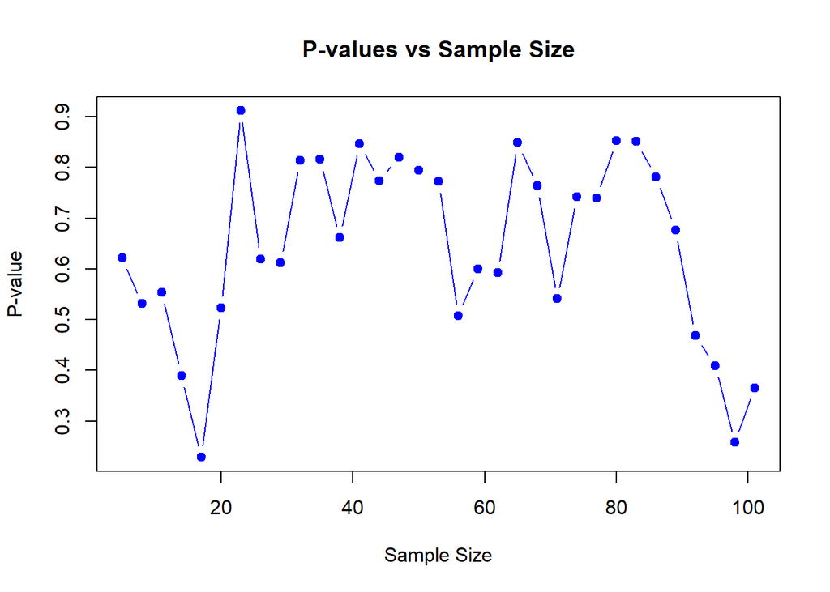

```r
# Set the seed for reproducibility
set.seed(123)

# Start with 5 random numbers from N(0,1)
sample_data <- rnorm(5)

# Initialize vectors to store sample size and p-values
sample_sizes <- length(sample_data)
p_values <- t.test(sample_data, mu = 0)$p.value

# Run a while-loop: keep adding 3 numbers each time
while (length(sample_data) < 100) { # stop once sample size gets reasonably big
  # Add 3 new random numbers
  sample_data <- c(sample_data, rnorm(3))

  # Perform t-test
  p_val <- t.test(sample_data, mu = 0)$p.value

  # Store results
  sample_sizes <- c(sample_sizes, length(sample_data))
  p_values <- c(p_values, p_val)
}

# Plot p-values vs sample size
plot(sample_sizes, p_values,
  type = "b", pch = 19, col = "blue",
  xlab = "Sample Size", ylab = "P-value", main = "P-values vs Sample Size"
)
abline(h = 0.05, col = "red", lty = 2) # Add a horizontal line at 0.05
```